# Videogrammetry Metrics for Assessing Fish Foraging Behavior: Implications for Behavioral Ecology and Management

Keane Flynn

4/30/2019

# **Introduction**

[output not shown]

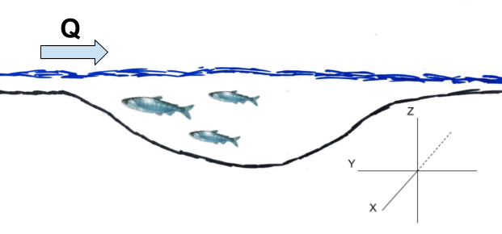

**Figure 1** *Profile view of a pool-riffle sequence with X, Y, Z planes relative to a fish maintaining positive rheotaxis.*

[output not shown]

# Methods

### *Streamside set up and use*

[output not shown]

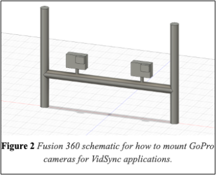

[output not shown]

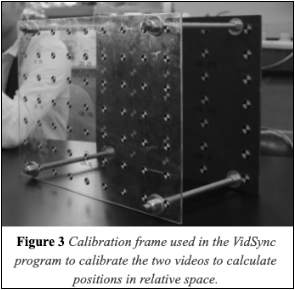

### *Video Period Selection*

The first 5 minutes of the video will be discarded to allow for an adjustment period to allow fish to resume normal foraging behavior (Nakano et al. 1999; Fausch et al. 1997). The video period being chosen will be randomly selected but first we must, by a quick scan sample, find the most fish-dense 10 minute period of the recording. In order, each 30 second interval of the video is then assigned an integer (1-20) and using a random number generator, 6 random integers (1-20) representing a unique 30 second period are selected to make up a total of 3 minutes of data supported behavioral observations (Neuswanger 2014; Rossi et al. 2019 in prep). Each of these 6 chosen integers will represent a subsample within the sample video to allow for a period of total observation similar to what has been previously used with this method, however it allows for a higher sample size while removing any potential bias in sampling period.

# R-code and Examplary Data for Quantitative and Qualitative Behavioral Metrics

## Load Libraries

```r
library(dplyr)
library(readr)
library(tidyverse)
```

```r
library(ggplot2)
library(lubridate)
library(geometry)
library(rgl)
library(hypervolume)
library(zoo)
library(stringr)
library(data.table)
```

# Importing VidSync CSV File

```r
VidSync_Test_Data <- readr::read_csv(file = "Porter_BACI_RoachRun_5July2018_Part1.csv",
                             skip = 2,
                             col_names = c("objects", "event", "timecode", "time_sec", "X", "Y", "Z", "pld_error", "projection_error", "nearest_camera_distance", "screen_coordinates"),
                    col_types = "cccdddddddd") %>%
  mutate(subsample = as.numeric(str_extract(objects, "\\d"))) %>%
  mutate(fish_ID = as.numeric(str_extract(objects, "\\h\\d{1,2}"))) %>%
  mutate(species = str_extract(objects, "Omykiss|Okisutch")) %>% #Note that the use of regular expressions in this line are to be specified to whatever species are recorded in your experiment
  select(subsample, fish_ID, species, time_sec, X, Y, Z, objects, event) #All other data vectors were excluded for the sake of neatness and what is useful in the metrics below
```

# Nearest Neighbor Distance (NND)

NND is calculated by finding the nearest neighbor to each unique fish over the course of a subsample. The final NND column will represent the closest nearest neighbor for each fish and exclude any larger distances (in cm) so as to not skew the data away from any values that are the absolute nearest neighbor point over the course of the subsample. It is important to note that subsamples with only one observed fish will produce an NND that is infinite and should be dealt with accordingly when graphing/calculating statistics on these values.

```r
NND_Data <- VidSync_Test_Data %>%
  filter(grepl("^Subsample.*", objects)) %>%
  filter(!grepl("^Length.*", event)) %>%
  filter(!grepl("^Attack.*", event)) %>%
  filter(!grepl("^Nip.*", event)) %>%
  na.omit() %>% #To remove any additional rows from the data set not associated with fish (i.e. surface shots)
  arrange(time_sec) %>%
  group_by(time_sec) %>%
  mutate(distance_between_X = X - lag(X, default = first(X))) %>%
  mutate(distance_between_Y = Y - lag(Y, default = first(Y))) %>%
  mutate(distance_between_Z = Z - lag(Z, default = first(Z))) %>%
  mutate(nnd_cm = sqrt((distance_between_X)^2 +
                      (distance_between_Y)^2 +
                      (distance_between_Z)^2)) %>%
  group_by(time_sec) %>%
  filter(!nnd_cm == 0) %>%
  filter(nnd_cm == min(nnd_cm)) %>%
  ungroup() %>%
  distinct(fish_ID, .keep_all = TRUE) %>%
  arrange(subsample, fish_ID, time_sec) %>%
  select(subsample, fish_ID, time_sec, nnd_cm)
```

# Distance per Time

```r
DistancePerTime_Data <- VidSync_Test_Data %>%
  filter(!grepl("Surface_Shots.*", objects)) %>%
  filter(!grepl("^Length.*", event)) %>%
  group_by(fish_ID) %>%
  mutate(distance_travelled_X_cm = X - lag(X, default = first(X))) %>%
  mutate(distance_travelled_Y_cm = Y - lag(Y, default = first(Y))) %>%
  mutate(distance_travelled_Z_cm = Z - lag(Z, default = first(Z))) %>%
  mutate(fish_distance_travelled_cm = sqrt((distance_travelled_X_cm)^2
                                        + (distance_travelled_Y_cm)^2
                                        + (distance_travelled_Z_cm)^2)) %>%
  ungroup() %>%
  group_by(fish_ID) %>%
  mutate(distance_cm_per_sec = fish_distance_travelled_cm /(time_sec - lag(time_sec, default = first(time_sec)))) %>%
  filter(!distance_cm_per_sec == Inf) %>%
  arrange(subsample, fish_ID, time_sec) %>%
  select(subsample, fish_ID, time_sec, distance_cm_per_sec)
```

# Proportion of Forage Behaviors

```r
ForageBehaviors_Data <- VidSync_Test_Data %>%
  filter(!grepl("Surface_Shots.*", objects)) %>%
  filter(!grepl("^Length.*", event)) %>%
  mutate(Behaviors = if_else(grepl("^Drift_Forage", event), "Drift Forage",
                     if_else(grepl("^Search_Forage", event), "Search Forage",
                     if_else(grepl("^Search_Forage", event), "Search Forage",
                     if_else(grepl("^Benthic_Forage", event), "Benthic Forage",
                     if_else(grepl("Nip|Attack", event), "Attack",
                     if_else(grepl("^Surface_Strike", event), "Surface Strike",
                     if_else(grepl("^Movement", event), "Movement", "NA")))))))) %>% #Note that "nip" has since been changed to the definition of "attack" and attack to feint
  arrange(subsample, fish_ID, time_sec) %>%
  select(subsample, fish_ID, time_sec, Behaviors)
```

# Centroid to Forage Attempt Point

```r
ControidToForage_Data <- VidSync_Test_Data %>%
  filter(!grepl("Surface_Shots.*", objects)) %>%
  filter(!grepl("^Length.*", event))
ControidToForage_Data
```

```
## # A tibble: 298 x 9
##    subsample fish_ID species  time_sec     X     Y     Z objects    event
##        <dbl>   <dbl> <chr>       <dbl> <dbl> <dbl> <dbl> <chr>      <chr>
##  1         1       1 Okisutch     450.  45.8  18.3  19.5 Subsample… Drift…
##  2         1       1 Okisutch     453.  45.5  20.5  19.7 Subsample… Drift…
##  3         1       1 Okisutch     456.  51.0  23.2  20.9 Subsample… Drift…
##  4         1       1 Okisutch     459.  52.1  21.0  18.1 Subsample… Surfa…
##  5         1       1 Okisutch     462.  47.7  19.5  21.3 Subsample… Drift…
##  6         1       1 Okisutch     465.  54.7  22.1  21.8 Subsample… Drift…
##  7         1       1 Okisutch     468.  54.4  21.7  19.5 Subsample… Drift…
##  8         1       1 Okisutch     471.  45.2  21.0  22.5 Subsample… Drift…
##  9         1       1 Okisutch     474.  48.0  18.7  21.9 Subsample… Drift…
## 10         1       1 Okisutch     477.  39.4  22.2  21.4 Subsample… Drift…
## # ... with 288 more rows
```